# Geographic data in R

```r
library(sf)
library(spData)
library(tidyverse)
library(sfheaders)
library(terra)
library(units)
```

# 1 Prerrequisites

Install the following packages:

```r
install.packages("sf")
install.packages("terra")
install.packages("spData")
install.packages(
    "spDataLarge",
    repos = "https://geocompr.r-universe.dev")
```

For linux check the [Posit Public Package Manager](https://packagemanager.posit.co) and apply the `SETUP` for your case. This repository is configured by default using Positron. Check:

```r
getOption("repos")
```

For example for `Ubuntu 24.04 LTS`:

```
                                                          P3M
"https://packagemanager.posit.co/cran/__linux__/noble/latest"
                                                         CRAN
                                "https://cloud.r-project.org"
```

# 2 Introduction

Fundamental geographic data models:

- Vector
- Raster

The **vector data model** represents the world using points, lines and polygons. The **raster data model** divides the surface up into cells of constant size.

Which to use?

- Vector data tends to dominate the social sciences because human settlements tend to have discrete borders
- Raster dominates many enfironmental sciences partially becasue the reliance on remote sensing data

# 3 Vector data

The geographic vecto data model is based on points located withing a coordinate reference system, **CRS**.

Points ca represent self-standing features or they can be linked together to form more complex geometries such as lines and polygons.

IN this system, for example, London can be represented by the coordinates `c(-0.1, 51.5)`. This means that its location is `-0.1` degrees east and `51.5` degrees north of the origin. The origin in this case is at `0` degrees longitude (Prime Meridian) and `0` degrees latitude (Equator) in a geographic (lon/lat) CRS.

For this section, it is sufficient to know that coordinates consist of two numbers representing distances from an origin, usually in $x$ and $y$ dimensions.

## 3.1 `sf` package

- **GDAL**: reading, writing and manipulating geographic data formats
- **PROJ**: coordinate system transformations
- **GEOS**: planar geometry engine for operations such as calculating buffers and centroids on data with a projected CRS
- **S2**: a spherical geometry engine

### 3.1.1 Simple features

Simple features is an open standard developed and endorsed by the Open Geospatial Consortium (OGC). Simple features is a hierarchical data model taht represents a wide rande of geometry types.

Simple feature types fully supported by `sf`:

- Multilinestring
- Multipoint
- Multipolygon
- Geometry collection
- Polygon
- Point
- Line string

Raster data classes are not supported by `sf`. For more information check the site [Simple Features for R](https://r-spatial.github.io/sf/) and the vignettes:

```r
vignette(package = "sf")
vignetter("sf1")
```

Simple feature objects in R are store in a data frame, with geographic data occupying a special column, usually name `geom` or `geometry`.

We are going to use the `world` dataset provided by `spData`:

```r
class(world)
```

```
[1] "sf"         "tbl_df"     "tbl"        "data.frame"
```

```r
names(world)
```

```
 [1] "iso_a2"    "name_long" "continent" "region_un" "subregion" "type"
 [7] "area_km2"  "pop"       "lifeExp"   "gdpPercap" "geom"
```

`sf` objects can be plotted quickly with the function `plot()`. For example:

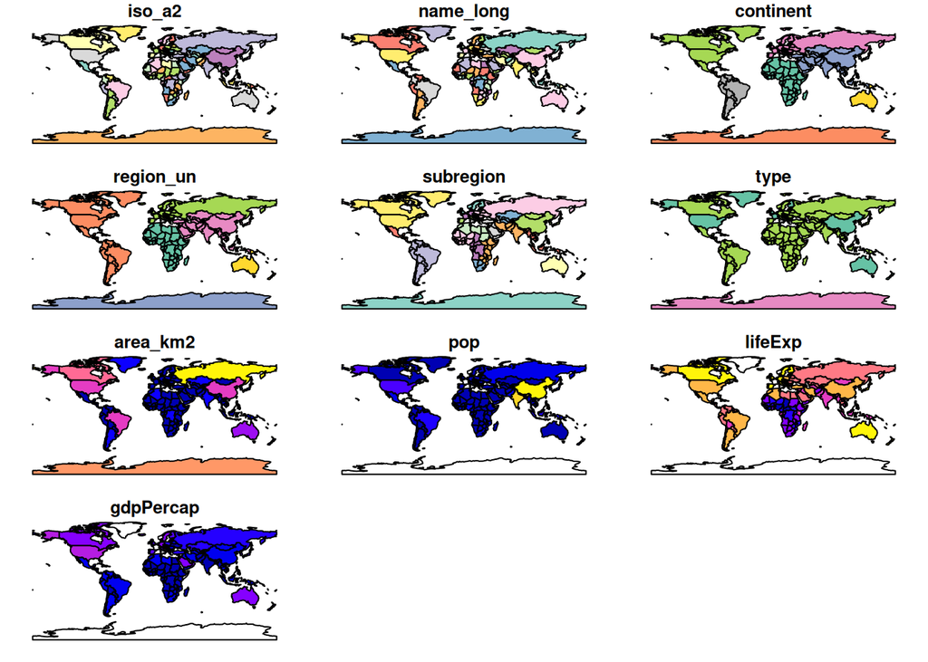

```r
plot(world, max.plot = 10)
```

In this case 10 variables from `world` are plot except `geom` where are the polygons. Also treating geographic objects as regular data frames with spatial powers nas many advantages, especially if you are already used to working with data frames.

```r
world["lifeExp"] |>
  summary()
```

```
    lifeExp                 geom
 Min.   :50.62   MULTIPOLYGON :177
 1st Qu.:64.96   epsg:4326    :  0
 Median :72.87   +proj=long...:  0
 Mean   :70.85
 3rd Qu.:76.78
 Max.   :83.59
 NA's   :10
```

In this case also the geometry (`geom`) is reported and the world `MULTIPOLYGON` in the output referts to the geometry type of features (countries) in the `world` object.

`sf` objects are easy to subset. For example you can return only the first 2 rows and the first 3 columns of the `world` object.

```r
world_mini <- world[1:2, 1:3]
world_mini
```

```
Simple feature collection with 2 features and 3 fields
Geometry type: MULTIPOLYGON
Dimension:     XY
Bounding box:  xmin: -180 ymin: -18.28799 xmax: 180 ymax: -0.95
Geodetic CRS:  WGS 84
# A tibble: 2 × 4
  iso_a2 name_long continent                                                geom
  <chr>  <chr>     <chr>                                      <MULTIPOLYGON [°]>
1 FJ     Fiji      Oceania   (((-180 -16.55522, -179.9174 -16.50178, -179.7933 …
2 TZ     Tanzania  Africa    (((33.90371 -0.95, 31.86617 -1.02736, 30.76986 -1.…
```

In a `sf` object, the geometry column is considered the defining characteristic of the data. Without the geometry, the object ceases to be spatial. That is why, `sf` is designed to ensure that the spatial integrity of the features remains intact.

The output shows two major differences compared with a regular `data.frame`: the inclusion of additional geographic metadata (`Geometry type`, `Dimension`, `Bounding box` and coordinate references system information). Also it has the `geom` column.

```r
world$geom |>
  class()
```

```
[1] "sfc_MULTIPOLYGON" "sfc"
```

`sfc` objects are composed of one or more objects of class `sfg`: simple features geometries.

### 3.1.2 Why simple features?

- Fast reading and writing of data
- Enhanced plotting performance
- `sf` objects can be treated as data frames in most operations
- `sf` function names are relatively consistent and intuitive (all begin with `st_`)
- `sf` functions can be combined with the `|>` operator and works well with the `tidyverse` collection of R packages

`sf` support for the `tidyverse` packages is exemplified by `read_sf()`, a function for importing geographic vector data. Unlike the function `st_read()`, which returns attributes stored in a base R `data.frame`, `read_sf()` silently returns data as a tidyverse `tibble`. For example:

```r
world_dfr <- system.file(
  "shapes/world.gpkg",
  package = "spData"
) |>
  st_read()
world_tbl <- system.file(
  "shapes/world.gpkg",
  package = "spData"
) |>
  read_sf()

class(world_dfr)
```

```
[1] "sf"         "data.frame"
```

```r
class(world_tbl)
```

```
[1] "sf"         "tbl_df"     "tbl"        "data.frame"
```

`world_tbl` include also the classes `tbl_df` and `tbl` additionally to `sf` and `data.frame`.

### 3.1.3 Basic maps

Basic geographic visualizations (maps) are created in `sf` with base R `plot()` function. Be default, this creates a multi-panel plot, one sub-plot for each variable of the object. For example:

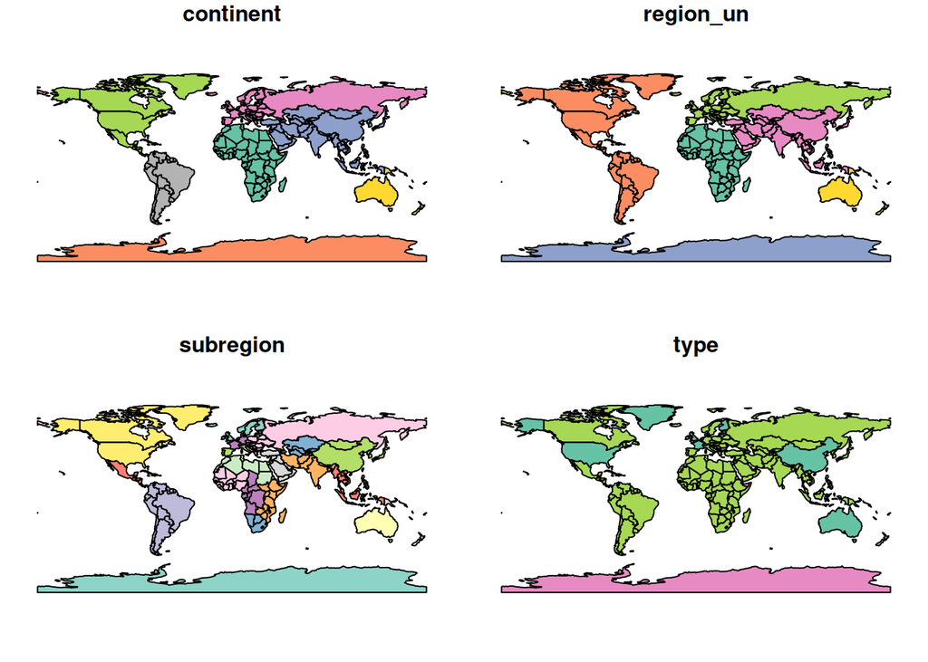

```r
plot(world[3:6])
```

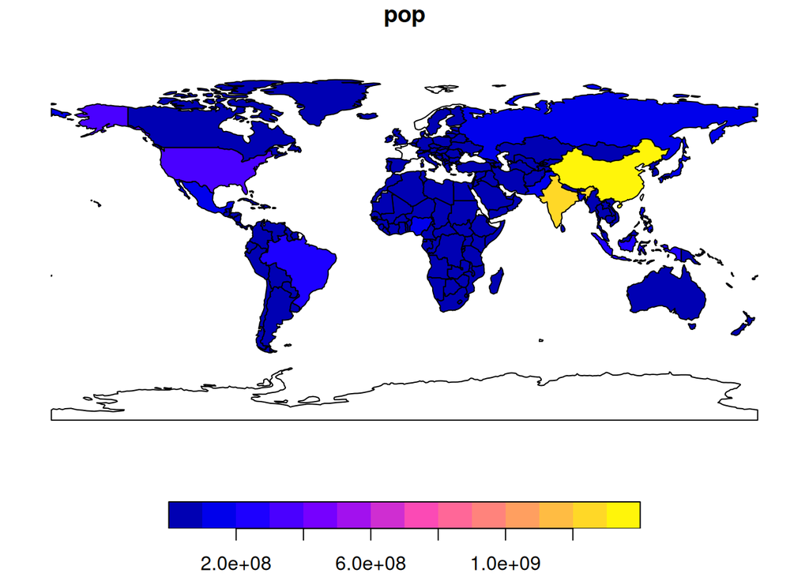

```r
plot(world["pop"])
```

`plot()` is a generic method that behaves differently depending on the class of object beign plotted. For example, you can check `methods(plot)`:

```r
methods(plot)[methods(plot) == "plot.sf"]
```

```
[1] "plot.sf"
```

Plots are added as layers to existing images by setting `add = TRUE`. For example lets filter the countries in Asia and combines then into a single feature:

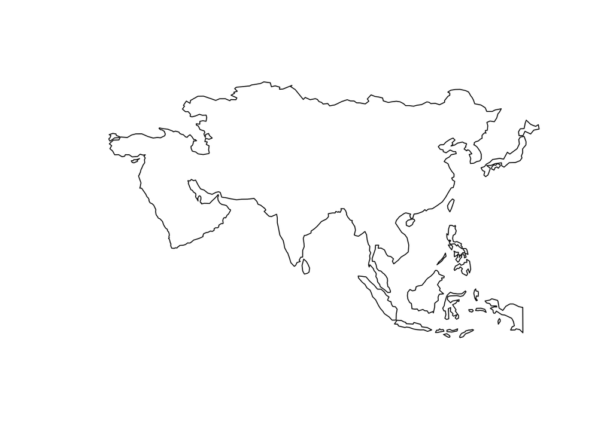

```r
world_asia <- world[world$continent == "Asia", ]
# A single MULTIPOLYGON is created that represents Asia
# as a single unit
asia <- st_union(world_asia)
plot(asia)
```

We can now plot the Asian continent over a map of the world. The first plot must only have one facet for `add = TRUE`. Also if the first plot has a key (a legend, for example a color scale to represent the data) then you need to specify `reset = FALSE`

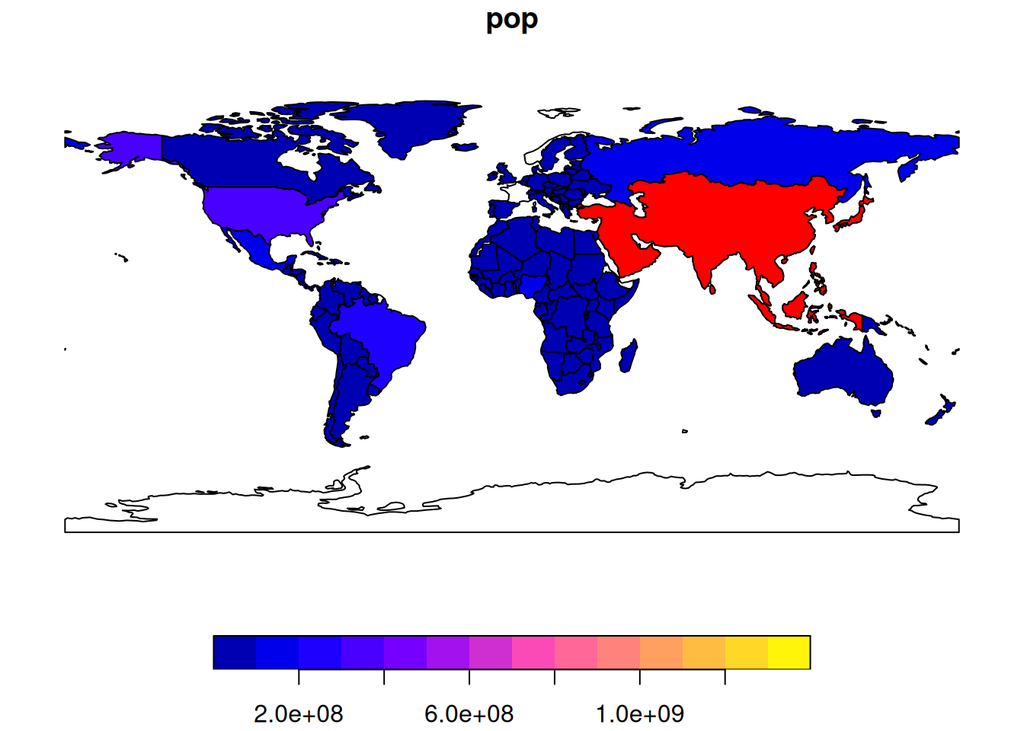

```r
plot(world["pop"], reset = FALSE)
plot(asia, add = TRUE, col = "red")
```

**Note**: This plot is problematic because the legend shows a fill scale to represent the population for the countries except asia.

Lets try another visualization by adding circles that represent the population on a map of the world as an unprojected version:

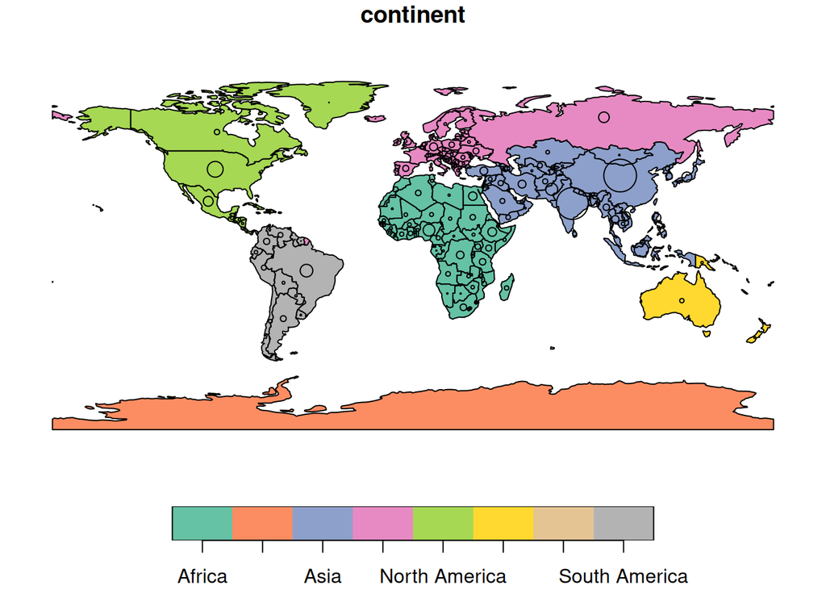

```r
plot(world["continent"], reset = FALSE)
cex <- sqrt(world$pop) / 10000
world_cents <- st_centroid(world, of_largest_polygon = TRUE)
plot(st_geometry(world_cents), add = TRUE, cex = cex)
```

In this case `st_centroid` gives the centroid of a geometry and the argument `of_largest_polygon` with the option `TRUE` finds the single part with the greatest area and uses its center. This is because many countries are multipoligons so by default a centroid might end up in the ocean between the mainland and an island.

`sf` plot method also has arguments specific to geographic data, `expandBB`, for example, can be used to plot and `sf` object in context: it takes a numeric vector of length four that expands the bounding box of the plot relative to zero in the following order:

- Bottom
- Left
- Top
- Right

This is used to plot india in the context of its giant Asian neighbors, with and emphasis on China to the east, in the following code chunk:

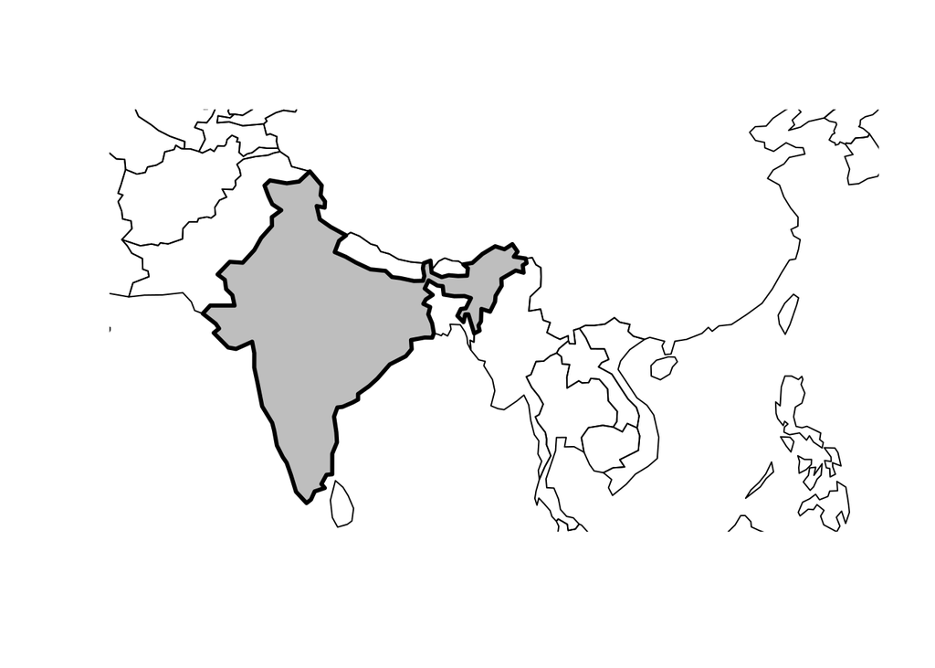

```r
india = world[world$name_long == "India", ]
plot(
  st_geometry(india),
  expandBB = c(0, 0.2, 0.1, 1),
  col = "gray",
  lwd = 3
)
plot(st_geometry(world_asia), add = TRUE)
```

### 3.1.4 Geometry types

Geometries are the basic building blocks of simple features. Simple features in R can take on one of the 18 geometry types supported by the `sf` package. In this part we will focus on:

- `POINT`
- `LINESTRING`
- `POLYGON`
- `MULTIPOINT`
- `MULTILINESTRING`
- `MULTYPOLYGON`
- `GEOMETRYCOLLECTION`

The basis for each geometry type is the point. A point is simply a coordinate in two-, three or four-dimensional space (see `vignetter("sf1")` for more information):

- `POINT (5,2)`

A linestring is a sequence of points with a straight line connectiong the points:

- `LINESTRING (1 5, 4 4, 4 1, 2 2, 3 2)`

A polygon is a sequence of points that form a closed, non-intersecting ring. Closed means that the first and the last point of a polygon have the same coordinates

- `POLYGON ((1 5, 2 2, 4 1, 4 4, 1 5))`

**Note**: See `1 5` at the start and end

So far we have created geometries with only one geometric entity per feature. Simple feature standard also allows multiple geometries of a single type to exist within a single feature with “multi” version of each geometry type.

- Multipoint: `MULTIPOINT (5 2, 1 3, 3 4, 3 2)`
- Multilinestring: `MULTILINESTRING ((1 5, 4 4, 4 1, 2 2, 3 2), (1 2, 2 4))`
- Multipolygon: `MULTIPOLYGON ((1 5, 2 2, 4 1, 4 4, 1 5), (0 2, 1 2, 1 3, 0 3, 0 2))`

Finally a geometry collection can contain any combination of geometries including (multi)points and linestrings.

- Geometry collection: `GEOMETRYCOLLECTION (MULTIPOINT (5 2, 1 3, 3 4, 3 2), LINESTRING (1 5, 4 4, 4 1, 2 2, 3 2))`

### 3.1.5 The sf class

Simple features consist of 2 main parts:

- Geometries
- Non-geographic attributes

Geometries come from a `sfc` object while non-geographic attributes are taken from a `data.frame` or `tibble`. Non-geographic attributes represent the name of the feature or other attributes such as measured values, groups and other things.

```r
lnd_point = st_point(c(0.1, 51.5)) # sfg object
lnd_geom = st_sfc(lnd_point, crs = "EPSG:4326") # sfc object
lnd_attrib = tibble(
  name = "London",
  temperature = 25,
  date = ymd("2023-06-21")
)
lnd_sf = st_sf(lnd_attrib, geometry = lnd_geom)
```

What just happened? First, the coordinates were used to create the simple feature geometry (`sfg`). Second, the geometry was converted into a simple feature geometry column (`sfc`), with a CRS. Third, attributes were stored in a `tibble`, which has combined with the `sfc`, with `st_sf()`. This results in an `sf` object, as demonstrated below:

```r
lnd_sf
```

```
Simple feature collection with 1 feature and 3 fields
Geometry type: POINT
Dimension:     XY
Bounding box:  xmin: 0.1 ymin: 51.5 xmax: 0.1 ymax: 51.5
Geodetic CRS:  WGS 84
# A tibble: 1 × 4
  name   temperature date          geometry
  <chr>        <dbl> <date>     <POINT [°]>
1 London          25 2023-06-21  (0.1 51.5)
```

```r
class(lnd_point)
```

```
[1] "XY"    "POINT" "sfg"
```

```r
class(lnd_geom)
```

```
[1] "sfc_POINT" "sfc"
```

```r
class(lnd_sf)
```

```
[1] "sf"         "tbl_df"     "tbl"        "data.frame"
```

### 3.1.6 Simple feature geometries (`sfg`)

The `sfg` class represents the different simple feature geomtry types in R:

- Point
- Linestring
- Polygon

And their “multi” equivalents.

Usually you are spared the tedious task of creating geometries on your own since you can simply import and already existing spatial file. However, there are a set of functions to create simple feature geomtry objects (`sfg`) from scratch, if needed.

The names of these functions are simple and consistent, as the all start with `st_` prefix and end with the name of the geometry type:

- A point: `st_point`
- A linestring: `st_linestring()`
- A polygon: `st_polygon`
- A multipoint: `st_multipoint()`
- A multilinestring: `st_multiline_string()`
- A multipolygon: `st_multipolygon()`
- A geometry collection: `st_geometrycollection()`

`sfg` objects can be created from 3 base R data types:

1. A numeric vector: a single point
2. A matrix: a set of points, where each row represents a point, a multipoint or linestring
3. A list: a colletion of objects such as matrices, multilinestrings or geometry collections

The function `st_point()` creates single points form numeric vectors:

```r
st_point(c(5, 2)) # XY point (2D)
```

```
POINT (5 2)
```

```r
st_point(c(5, 2, 3)) # XYZ point (3D)
```

```
POINT Z (5 2 3)
```

```r
st_point(c(5, 2, 1), dim = "XYM") # XYM point (3D with an additional variable, typically measurement accuracy)
```

```
POINT M (5 2 1)
```

```r
st_point(c(5, 2, 3, 1)) # XYZM
```

```
POINT ZM (5 2 3 1)
```

The `XYM` type must be specified using the `dim` argument (which is a short for dimension)

By contrast, use matrices in the case of multipoint (`st_multipoint()`) and linestring (`st_linestring`) objects:

```r
multipoint_matrix = rbind(
  c(5, 2),
  c(1, 3),
  c(3, 4),
  c(3, 2)
)
st_multipoint(multipoint_matrix)
```

```
MULTIPOINT ((5 2), (1 3), (3 4), (3 2))
```

```r
linestring_matrix = rbind(
  c(1, 5),
  c(4, 4),
  c(4, 1),
  c(2, 2),
  c(3, 2)
)
st_linestring(linestring_matrix)
```

```
LINESTRING (1 5, 4 4, 4 1, 2 2, 3 2)
```

Finally, use lists for the creation of multilinestrings, (multi-)polygons and geometry collections:

```r
## POLYGON
polygon_lists = list(
  rbind(
    c(1, 5),
    c(2, 2),
    c(4, 1),
    c(4, 4),
    c(1, 5)
  )
)
st_polygon(polygon_lists)
```

```
POLYGON ((1 5, 2 2, 4 1, 4 4, 1 5))
```

```r
# POLYGON with a hole
polygon_border = rbind(
  c(1, 5),
  c(2, 2),
  c(4, 1),
  c(4, 4),
  c(1, 5)
)
polygon_hole = rbind(
  c(2, 4),
  c(3, 4),
  c(3, 3),
  c(2, 3),
  c(2, 4)
)
polygon_with_hole_list = list(
  polygon_border,
  polygon_hole
)
st_polygon(polygon_with_hole_list)
```

```
POLYGON ((1 5, 2 2, 4 1, 4 4, 1 5), (2 4, 3 4, 3 3, 2 3, 2 4))
```

```r
# MULTILINESTRING
multilinestring_list = list(
  rbind(
    c(1, 5),
    c(4, 4),
    c(2, 2),
    c(3, 2)
  )
)
st_multilinestring(multilinestring_list)
```

```
MULTILINESTRING ((1 5, 4 4, 2 2, 3 2))
```

```r
# MULTIPOLYGON
multipolygon_list = list(
  list(
    rbind(
      c(1, 5),
      c(2, 2),
      c(4, 1),
      c(4, 4),
      c(1, 5)
    )
  ),
  list(
    rbind(
      c(0, 2),
      c(1, 2),
      c(1, 3),
      c(0, 3),
      c(0, 2)
    )
  )
)
st_multipolygon(multipolygon_list)
```

```
MULTIPOLYGON (((1 5, 2 2, 4 1, 4 4, 1 5)), ((0 2, 1 2, 1 3, 0 3, 0 2)))
```

```r
## GEOMETRYCOLLECTION
geometrycollection_list = list(
  st_multipoint(multipoint_matrix),
  st_linestring(linestring_matrix)
)
st_geometrycollection(geometrycollection_list)
```

```
GEOMETRYCOLLECTION (MULTIPOINT ((5 2), (1 3), (3 4), (3 2)), LINESTRING (1 5, 4 4, 4 1, 2 2, 3 2))
```

### 3.1.7 Simple feature columns (sfc)

For instance, to combine 2 simploe features into one object with 2 features, we can use the `st_sfc()` function. This is important since `sfc` represents the geometry column in `sf` data frames:

```r
# sfc POINT
point1 = st_point(c(5, 2))
point2 = st_point(c(1, 3))
points_sfc = st_sfc(point1, point2)
points_sfc
```

```
Geometry set for 2 features
Geometry type: POINT
Dimension:     XY
Bounding box:  xmin: 1 ymin: 2 xmax: 5 ymax: 3
CRS:           NA
```

```
POINT (5 2)
```

```
POINT (1 3)
```

In most cases, an `sfc` object contains objects of the same geometry type. Therefore, when we convert `sfg` objects of type plygon into a simple feature geometry column, we would also end up with an `sfc` object of type polygon, which can be verified with `st_geometry_type()`. Equally, a geometry column of multilinestrings would result in an `sfc` object of type multilinestring:

```r
# sfc POLYGON
polygon_list1 = list(
  rbind(
    c(1, 5),
    c(2, 2),
    c(4, 1),
    c(4, 4),
    c(1, 5)
  )
)
polygon1 = st_polygon(polygon_list1)
polygon_list2 = list(
  rbind(
    c(0, 2),
    c(1, 2),
    c(1, 3),
    c(0, 3),
    c(0, 2)
  )
)
polygon2 = st_polygon(polygon_list2)
polygon_sfc = st_sfc(
  polygon1,
  polygon2
)
st_geometry_type(polygon_sfc)
```

```
[1] POLYGON POLYGON
18 Levels: GEOMETRY POINT LINESTRING POLYGON MULTIPOINT ... TRIANGLE
```

```r
multilinestring_list1 = list(
  rbind(c(1, 5), c(4, 4), c(4, 1), c(2, 2), c(3, 2)),
  rbind(c(1, 2), c(2, 4))
)
multilinestring1 = st_multilinestring((multilinestring_list1))
multilinestring_list2 = list(
  rbind(c(2, 9), c(7, 9), c(5, 6), c(4, 7), c(2, 7)),
  rbind(c(1, 7), c(3, 8))
)
multilinestring2 = st_multilinestring((multilinestring_list2))
multilinestring_sfc = st_sfc(multilinestring1, multilinestring2)
st_geometry_type(multilinestring_sfc)
```

```
[1] MULTILINESTRING MULTILINESTRING
18 Levels: GEOMETRY POINT LINESTRING POLYGON MULTIPOINT ... TRIANGLE
```

It is also possible to create an `sfc` object from `sfg` objects with different geometry types:

```r
point_multilinestring_sfc = st_sfc(
  point1,
  multilinestring1
)
st_geometry(point_multilinestring_sfc)
```

```
Geometry set for 2 features
Geometry type: GEOMETRY
Dimension:     XY
Bounding box:  xmin: 1 ymin: 1 xmax: 5 ymax: 5
CRS:           NA
```

```
POINT (5 2)
```

```
MULTILINESTRING ((1 5, 4 4, 4 1, 2 2, 3 2), (1 ...
```

As mentioned before, `sfc` objects can additionally store information on the CRS. The default values is `NA` (NOT AVAILABLE), as can be verified with `st_crs()`:

```r
st_crs(points_sfc)
```

```
Coordinate Reference System: NA
```

All geometries in `sfc` objects must have the same CRS. ACRS can be specifies with the `crs` argument of `st_sfc()` (or `st_sf()`), which takes a CRS identifier provied as a text string, such as `crs = "EPSG:4326"`

```r
points_sfc_wgs = st_sfc(
  point1,
  point2,
  crs = "EPSG:4326"
)
st_crs(points_sfc_wgs)
```

```
Coordinate Reference System:
  User input: EPSG:4326
  wkt:
GEOGCRS["WGS 84",
    ENSEMBLE["World Geodetic System 1984 ensemble",
        MEMBER["World Geodetic System 1984 (Transit)"],
        MEMBER["World Geodetic System 1984 (G730)"],
        MEMBER["World Geodetic System 1984 (G873)"],
        MEMBER["World Geodetic System 1984 (G1150)"],
        MEMBER["World Geodetic System 1984 (G1674)"],
        MEMBER["World Geodetic System 1984 (G1762)"],
        MEMBER["World Geodetic System 1984 (G2139)"],
        ELLIPSOID["WGS 84",6378137,298.257223563,
            LENGTHUNIT["metre",1]],
        ENSEMBLEACCURACY[2.0]],
    PRIMEM["Greenwich",0,
        ANGLEUNIT["degree",0.0174532925199433]],
    CS[ellipsoidal,2],
        AXIS["geodetic latitude (Lat)",north,
            ORDER[1],
            ANGLEUNIT["degree",0.0174532925199433]],
        AXIS["geodetic longitude (Lon)",east,
            ORDER[2],
            ANGLEUNIT["degree",0.0174532925199433]],
    USAGE[
        SCOPE["Horizontal component of 3D system."],
        AREA["World."],
        BBOX[-90,-180,90,180]],
    ID["EPSG",4326]]
```

## 3.2 The sfheaders package

`sfheaders` is an R package that speeds-up the construction, conversion and manipulation of `sf` objects. If focuses on building `sf` objects from vectors, matrices and dataframes, rapidly without depending on the `sf` library.

The simples use case of `sfheaders` is demonstrated in the code chunks below with examples of building `sfg`, `sfc` and `sf` objects showing:

- A vector converted to `sfg_POINT`
- A matrix converted to `sfg_LINESTRING`
- A data frame converted to `sfg_POLYGON`

We will start by creating the simplest possible `sfg` object, a single coordinate pair, assigned to a vector named `v`:

```r
v = c(1, 1)
v_sfg_sfh = sfg_point(obj = v)
v_sfg_sfh
```

```
POINT (1 1)
```

```r
class(v_sfg_sfh)
```

```
[1] "XY"    "POINT" "sfg"
```

The next examples show how `sfheaders` creates `sfg` objects from matrices and data frames:

```r
# matrix
m = matrix(1:8, ncol = 2)
sfg_linestring(obj = m)
```

```
LINESTRING (1 5, 2 6, 3 7, 4 8)
```

```r
# dataframes
df = data.frame(x = 1:4, y = 4:1)
sfg_polygon(obj = df)
```

```
POLYGON ((1 4, 2 3, 3 2, 4 1, 1 4))
```

Reusing the objects `v`, `m` and `df` we can also build simple feature columns (`sfc`) as follows (ouputs not shown):

```r
sfc_point(obj = v)
```

```
Geometry set for 1 feature
Geometry type: POINT
Dimension:     XY
Bounding box:  xmin: 1 ymin: 1 xmax: 1 ymax: 1
CRS:           NA
```

```
POINT (1 1)
```

```r
sfc_linestring(obj = m)
```

```
Geometry set for 1 feature
Geometry type: LINESTRING
Dimension:     XY
Bounding box:  xmin: 1 ymin: 5 xmax: 4 ymax: 8
CRS:           NA
```

```
LINESTRING (1 5, 2 6, 3 7, 4 8)
```

```r
sfc_polygon(obj = df)
```

```
Geometry set for 1 feature
Geometry type: POLYGON
Dimension:     XY
Bounding box:  xmin: 1 ymin: 1 xmax: 4 ymax: 4
CRS:           NA
```

```
POLYGON ((1 4, 2 3, 3 2, 4 1, 1 4))
```

Similarly, `sf` objects can be created as follows:

```r
sf_point(obj = v)
```

```
Simple feature collection with 1 feature and 0 fields
Geometry type: POINT
Dimension:     XY
Bounding box:  xmin: 1 ymin: 1 xmax: 1 ymax: 1
CRS:           NA
     geometry
1 POINT (1 1)
```

```r
sf_linestring(obj = m)
```

```
Simple feature collection with 1 feature and 1 field
Geometry type: LINESTRING
Dimension:     XY
Bounding box:  xmin: 1 ymin: 5 xmax: 4 ymax: 8
CRS:           NA
  id                       geometry
1  1 LINESTRING (1 5, 2 6, 3 7, ...
```

```r
sf_polygon(obj = df)
```

```
Simple feature collection with 1 feature and 1 field
Geometry type: POLYGON
Dimension:     XY
Bounding box:  xmin: 1 ymin: 1 xmax: 4 ymax: 4
CRS:           NA
  id                       geometry
1  1 POLYGON ((1 4, 2 3, 3 2, 4 ...
```

In each of these examples, the CRS is not defined. If you plan on doing any calculations or geometric operations using `sf` functions, we encourage you to set the CRS:

```r
df_sf = sf_polygon(obj = df)
st_crs(df_sf) = "EPSG:4326"
```

## 3.3 Sphericla geometry operations in S2

Spherical geometry engines are based on the fact that the world is round, while simple mathematical procedures for geocomputation, such as calculating a straight line between 2 points of the are enclosed in a polygon, assume planar (projected) geometries.

Since `sf` version 1.0.0, R supports spherical geometry operations out of the box (and by default), thanks to its interface to Google’s S2 speherical geometry engine via the `s2` interface package. S2 is perhaps best known as an example of a Discrte Global Grid System (DGGS). Another example is the H3 global hexagonal hierachical spatial index.

`sf` can run in 2 modes with respect to S2: on and off. By default the S2 geometry engine is turned on, as can be verified with:

```r
sf_use_s2()
```

```
[1] TRUE
```

Throught this book, we will assume that S2 is turned on, unless explicitely stated.

# 4 Raster data

The spatial raster daa model represents the world with the continuous grid of cells (often also called pixels). the resolution can be calculated as follows:

$$resolution = \frac{xmax - xmin}{ncol}, \frac{ymax - ymin}{nrow}$$

Raster maps usually represent continuous phenomena such as elevation, temperature, population density or spectral data. Discrete features such as soil or land-cover classes can also be rperesented in the raster data model.

## 4.1 R packages for working with raster data

In this book we focus on `terra`, which replaces the older and in most cases slower `raster`.

## 4.2 Introduction to terra

The `terra` package supports raster objects in R. It provides an extensive set of functions to create, read, export, manipulate and process raster datasets.

For the illustration of `terra` concepts, we will use datasets from the `spDataLarge`. It consists of a few raster objects and one vector object covering an area of Zion National Park (Utah, USA).

For example `srtm.tif` is a digital evelvation model of this area (check `?srtm`)

First, let’s create a `SpatRaster` object named `my_rast`:

```r
raster_filepath = system.file(
  "raster/srtm.tif",
  package = "spDataLarge"
)
my_rast = rast(raster_filepath)
class(my_rast)
```

```
[1] "SpatRaster"
attr(,"package")
[1] "terra"
```

Typing the name of the raster into the console, will print out the raster header (dimensions, resolution, extent, CRS) and some additional information (class, data, source, summany of the raster values):

```r
my_rast
```

```
class       : SpatRaster
size        : 457, 465, 1  (nrow, ncol, nlyr)
resolution  : 0.0008333333, 0.0008333333  (x, y)
extent      : -113.2396, -112.8521, 37.13208, 37.51292  (xmin, xmax, ymin, ymax)
coord. ref. : lon/lat WGS 84 (EPSG:4326)
source      : srtm.tif
name        : srtm
min value   : 1024
max value   : 2892
```

## 4.3 Basic map-making

Similar to the `sf` package, `terra` also provides `plot()` methods for its own classes. As shown in the following command, the `plot()` function creates a basic raster plot.

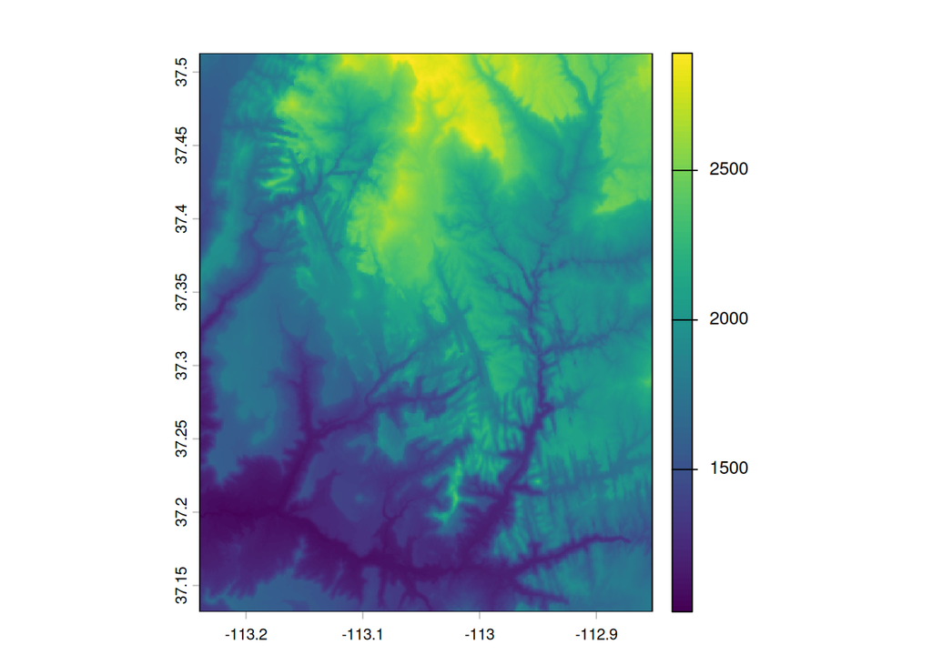

```r
plot(my_rast)
```

## 4.4 Raster classes

The `SpatRaster` class represents raster object of **terra**. The easiest way to create a raster object in R is to read-in raster file from disk or from a server.

```r
single_raster_file = system.file(
  "raster/srtm.tif",
  package = "spDataLarge"
)
single_rast = rast(raster_filepath)
```

Raster can also be created from scratch, using the same `rast()` function. This is illustrated in the subsequent code chunk, which results in a new `SpatRaster` object.

The resulting raster consists of 36 cells (6 columns and 6 rows specified by `nrows` and `ncols`) centered around the Prime Meridian and the Equator (see `xmin`, `xmax`, `ymin`, `ymax` parameters).

Values (`vals`) are assigned to each cell: 1 to cell 1, 2 to cell 2, and so on. For other ways of creating raster objects, see `?rast`.

```r
new_raster = rast(
  nrows = 6,
  ncols = 6,
  xmin = -1.5,
  xmax = 1.5,
  ymin = -1.5,
  ymax = 1.5,
  vals = 1:36
)
new_raster
```

```
class       : SpatRaster
size        : 6, 6, 1  (nrow, ncol, nlyr)
resolution  : 0.5, 0.5  (x, y)
extent      : -1.5, 1.5, -1.5, 1.5  (xmin, xmax, ymin, ymax)
coord. ref. : lon/lat WGS 84 (CRS84) (OGC:CRS84)
source(s)   : memory
name        : lyr.1
min value   :     1
max value   :    36
```

In this case the resolution is:

$$resolution = \frac{1.5 - (-1.5)}{6}, \frac{1.5 - (-1.5)}{6} = \frac{3}{6}, \frac{3}{6} = 0.5, 0.5$$

A way to understand this `new_raster` object is to convert is as a matrix:

```r
as.matrix(
  new_raster,
  wide = TRUE
)
```

```
     [,1] [,2] [,3] [,4] [,5] [,6]
[1,]    1    2    3    4    5    6
[2,]    7    8    9   10   11   12
[3,]   13   14   15   16   17   18
[4,]   19   20   21   22   23   24
[5,]   25   26   27   28   29   30
[6,]   31   32   33   34   35   36
```

The unit of the resolution is that of the underlying CRS. Here, it is degrees, because the default CRS of raster objects is WGS84. However, one can specify any other CRS with the `crs` argument.

The `SpatRatester` class also handles multiple layers, which typically corresponds to a single multi-spectral satellite fiel or a time-series of rasters.

```r
multi_raster_file = system.file(
  "raster/landsat.tif",
  package = "spDataLarge"
)
multi_rast = rast(multi_raster_file)
multi_rast
```

```
class       : SpatRaster
size        : 1428, 1128, 4  (nrow, ncol, nlyr)
resolution  : 30, 30  (x, y)
extent      : 301905, 335745, 4111245, 4154085  (xmin, xmax, ymin, ymax)
coord. ref. : WGS 84 / UTM zone 12N (EPSG:32612)
source      : landsat.tif
names       : landsat_1, landsat_2, landsat_3, landsat_4
min values  :      7550,      6404,      5678,      5252
max values  :     19071,     22051,     25780,     31961
```

`nlyr` retrieves the number of layers stored in a `SpatRaster` object:

```r
nlyr(multi_rast)
```

```
[1] 4
```

For multi-layer raster objects, layers ca be selected with `[[` and `$` operators, for example with commands `multi_rast[["landsat_1]]` and `muti_rast$landsat_1`. The `terra::subset()` can also be used to select layers. It accepts a layer number or its name as the second argument:

```r
multi_rast3 = subset(multi_rast, 3)
multi_rast3
```

```
class       : SpatRaster
size        : 1428, 1128, 1  (nrow, ncol, nlyr)
resolution  : 30, 30  (x, y)
extent      : 301905, 335745, 4111245, 4154085  (xmin, xmax, ymin, ymax)
coord. ref. : WGS 84 / UTM zone 12N (EPSG:32612)
source      : landsat.tif
name        : landsat_3
min value   :      5678
max value   :     25780
```

```r
multi_rast4 = subset(multi_rast, "landsat_4")
multi_rast4
```

```
class       : SpatRaster
size        : 1428, 1128, 1  (nrow, ncol, nlyr)
resolution  : 30, 30  (x, y)
extent      : 301905, 335745, 4111245, 4154085  (xmin, xmax, ymin, ymax)
coord. ref. : WGS 84 / UTM zone 12N (EPSG:32612)
source      : landsat.tif
name        : landsat_4
min value   :      5252
max value   :     31961
```

The opposite operation, combining several `SpatRaster` objects into one, can be donde using the `c` function:

```r
multi_rast34 = c(
  multi_rast3,
  multi_rast4
)
```

# 5 Coordinate Reference Systems (CRS)

CRS defines how the spatial elements of the data relate to the surve of the Earth (or other bodies). CRS are either geographic or projected.

## 5.1 Geographic coordinate reference systems

Geographic CRS’s identify any location on the Earth’s surface using 2 values: longitude and latitude. Longitude is location in the East-West direction in angular distance form the Prime Meridian plane. Latitude is angular distance North or South of the equatorial plane.

Distances in geographic CRS are therefore not measured in meters. The surface of the Earth in geographic CRS’s is represented by a spherical or ellipsoidal surface. Speherical models assume that the Earth is a perfect sphere of a given radius, they gave the advantage of simplicity but, at the same time, they are inaccurate as the Earth is not exactly a sphere.

Ellipsoidal models are slightly more accurate, and are defined by 2 parameters: the equatiorial radius and the polar radius.

Ellipsoids are part of a wider component of CRS’s: the datum. This contains information on what ellipsoid to use and the precise relationship between the corrdinates and location on the Earth’s surface. There are 2 types of datum:

- Geometric (such as `WGS84`)
- Local (such as `NAD83`)

## 5.2 Projected coordinate reference systems

All projected CRS’s are based on a geographic CRS, described in the previous section, and rely on map projections to convert the 3-dimensional surface of the EArh into Easting and Northing (x and y) values in a projected CRS.

Projected CRS’s are based on Cartesian coordinates on an implicitly flat surface. They have and origin, x and y axes, and a linear unit of measurement such as meters.

This transition cannot be done without adding some deformations. Therefore, some properties of the Earth’s surfave are distorted in this process, such as area, direction, distanca and shape. A projected coordiante reference system can preserve only 1 or 2 of those properties.

There are 3 main groups of prjection types: conic, cylindrical and planar (azimuthal). A quick summary of different projections, their types, properties and suitability can be found at [www.geo-projections.com](https://www.geo-projections.com/)

For now, it is sufficient to know:

- That coordinate systems are key componet of geographic objects
- Which CRS you data is in and whether it is geographic (longitude/latitude) or projected (typically meters), is important and has conseguiences for how R handles spatial and geometry operations
- That CRs’s of `sf` objects can be queried with the function `st_crs()` and CRS’s of terra ojbects can be queried with the function `crs()`

# 6 Units

An important feature of CRS’s is that they contain information about spatial units. It is good cartographic practice to add a scale bar or some other distance indicator onto maps to demonstrate the relationship between distances on the page or screen and idstances on the ground.

A novel feature of geometry data in `sf` objects is that they have native support for units. This means that distance, area and other geometric calculations in `sf` return values that come with a `units` attribute, defined by the `units` package.

For example lets demonstrate the calculation of the area of Luxembourg:

```r
luxembourg <- world[world$name_long == "Luxembourg", ]
st_area(luxembourg)
```

```
2408817306 [m^2]
```

The out is in units of square meters (m2), showing that the result represents 2-dimensional space.

If you want to change the units you can use the `units` package:

```r
units::set_units(st_area(luxembourg), value = km^2)
```

```
2408.817 [km^2]
```

Units are of equal importante in the case of raster data. However, so far `sf` is the only spatial package that supports units, meaning that people working on raster data should approach changes in the units of analysis with case.

# 7 Exercises

**Exercise 1** Use `summary` on geometry column of the `world` data object that is included in the `spData` package. What does the output tell us about:

- The geometry type?
- The number or countries?
- Its coordinate reference system (CRS)?

**Exercise 2** Run the code that ‘generated’ the map of the world in Section 2.2.3 (Basic map-making). Find two similarities and two differences between the image on your computer and that in the book.

- What does the cex argument do (see ?plot)?
- Why was cex set to the sqrt(world$pop) / 10000?
- Bonus: experiment with different ways to visualize the global population.

*Solution 2*. I this case we have the following:

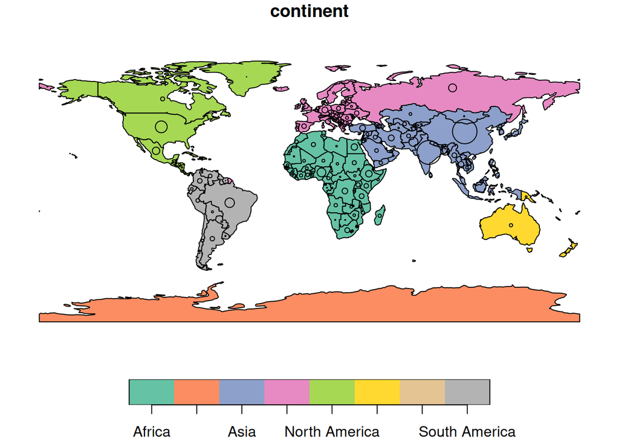

```r
plot(world["continent"], reset = FALSE)
cex <- sqrt(world$pop) / 10000
world_cents <- st_centroid(world, of_largest_polygon = TRUE)
plot(st_geometry(world_cents), add = TRUE, cex = cex)
```

The different is that the centroids that represent the population are distorted. Also I obtain a legend with the continents. In the case of the similarities I obtain the same colors and the plot in a different geometry.

- The meaning of cex gives the amout by which plotting characters and symbols should be scales relative to the default.
- You need to rescale every that of the population

**Exercise 3** Use `plot()` to create maps of Nigeria in context

- Adjust `lwd`, `col` and `expandBB`
- Read the documentation of `text()` and annotate the map

*Solution 3*.

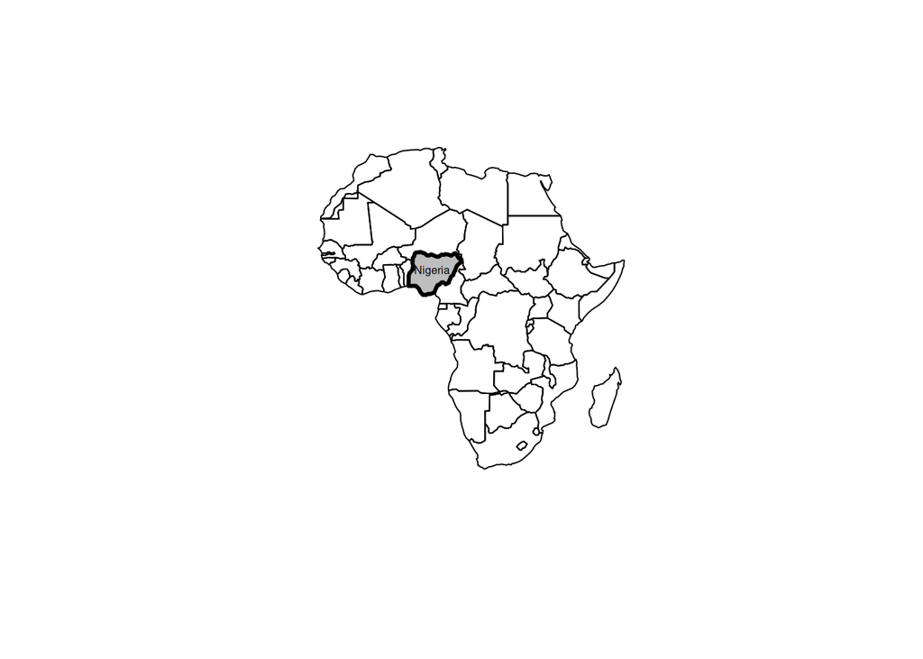

```r
nigeria = world[world$name_long == "Nigeria", ]
world_africa = world[world$continent == "Africa", ]

# Coordinates
coords_nigeria = nigeria |>
  st_centroid() |>
  st_coordinates()

plot(
  st_geometry(nigeria),
  # c(bottom, left, top, right)
  expandBB = c(5, 2, 3, 4),
  col = "gray",
  lwd = 3
)
plot(st_geometry(world_africa), add = TRUE)
text(
  x = coords_nigeria[1, 1],
  y = coords_nigeria[1, 2],
  labels = "Nigeria",
  cex = 0.5
)
```

**Exercise 4** Create an empty `SpatRaster` object called `my_raster` with 10 columns and 10 rows. Assign random values between `0` and `10` to the new raster and plot it.

*Solution 4*.

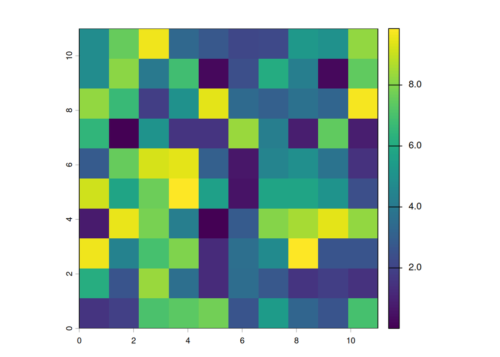

```r
my_raster <- rast(
  nrows = 10,
  ncols = 10,
  xmin = 0,
  xmax = 11,
  ymin = 0,
  ymax = 11,
  vals = runif(n = 100, min = 0, max = 10)
)

plot(my_raster)
```

**Exercise 5** Read-in the `raster/nlcd.tif` file from the `spDataLarge` package. What kind of information can you get about the properties of this file?

*Solution 5*.

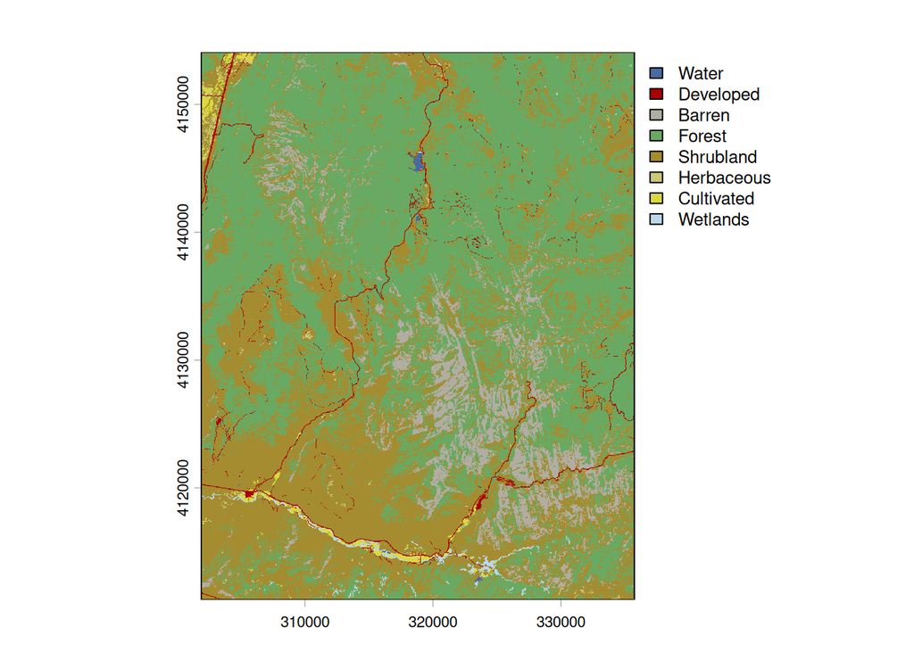

```r
raster_filepath <- system.file(
  "raster/nlcd.tif",
  package = "spDataLarge"
)

my_raster_2 <- rast(raster_filepath)

plot(my_raster_2)
```

**Exercise 6** Check the CRS of the `raster/nlcd.tif` file form the `spDataLarge` package. What kind of information you can learn from it?

*Solution 6*.

```r
st_crs(my_raster_2)
```

```
Coordinate Reference System:
  User input: NAD83 / UTM zone 12N
  wkt:
PROJCRS["NAD83 / UTM zone 12N",
    BASEGEOGCRS["NAD83",
        DATUM["North American Datum 1983",
            ELLIPSOID["GRS 1980",6378137,298.257222101,
                LENGTHUNIT["metre",1]]],
        PRIMEM["Greenwich",0,
            ANGLEUNIT["degree",0.0174532925199433]],
        ID["EPSG",4269]],
    CONVERSION["UTM zone 12N",
        METHOD["Transverse Mercator",
            ID["EPSG",9807]],
        PARAMETER["Latitude of natural origin",0,
            ANGLEUNIT["degree",0.0174532925199433],
            ID["EPSG",8801]],
        PARAMETER["Longitude of natural origin",-111,
            ANGLEUNIT["degree",0.0174532925199433],
            ID["EPSG",8802]],
        PARAMETER["Scale factor at natural origin",0.9996,
            SCALEUNIT["unity",1],
            ID["EPSG",8805]],
        PARAMETER["False easting",500000,
            LENGTHUNIT["metre",1],
            ID["EPSG",8806]],
        PARAMETER["False northing",0,
            LENGTHUNIT["metre",1],
            ID["EPSG",8807]]],
    CS[Cartesian,2],
        AXIS["(E)",east,
            ORDER[1],
            LENGTHUNIT["metre",1]],
        AXIS["(N)",north,
            ORDER[2],
            LENGTHUNIT["metre",1]],
    USAGE[
        SCOPE["Engineering survey, topographic mapping."],
        AREA["North America - between 114°W and 108°W - onshore and offshore. Canada - Alberta; Northwest Territories; Nunavut; Saskatchewan. United States (USA) - Arizona; Colorado; Idaho; Montana; New Mexico; Utah; Wyoming."],
        BBOX[31.33,-114,84,-108]],
    ID["EPSG",26912]]
```